# Case Study | Group 14

SoSe 2026 | Introduction to Data Analytics

## Group Members

| Name | Matrikelnummer |
| --- | --- |
| Ibrahim Gezer | 413044 |
| Cagatay Kulakac | 412636 |
| Fehmi Cem Yilmaz | 476211 |
| Erol Saka | 484257 |
| Leila Elkamel | 492215 |

- Case Study Assignment
- Analysis Plan
- Data Overview
- Manual Data Exploration
- 1. Importing the Data
- 2. Data Preparation
- 3. Creation of the Final Dataset
- 4. Evaluation and Results
- 5. Web Application

## Case Study Assignment

We are employees of the fictitious company "202", which sells individual parts to engine manufacturers. The engine manufacturers supply the automobile brands OEM1 and OEM2. The marketing department asks us to answer the following questions:

1. **Market share:** What is the market share of our company 202 parts compared to the competition?
2. **Defect frequency:** How does the defect frequency of our parts compare to the competition for OEM1 vehicles?
3. **Engine penetration:** In how many engines are parts from 202 installed? The result should support the slogan "In every xth engine there are parts from 202".
4. **Dashboard:** Present the results in an interactive web application.

Two constraints come with the task. The defect comparison is restricted to engines that were installed in OEM1 vehicles, and the production time range of the parts has to be freely selectable.

## Analysis Plan

Our company produces individual parts. Those parts are built into engines by a Tier 1 supplier, and the engines are installed in vehicles by the two OEMs. To answer the questions we therefore have to follow a part along this supply chain:

**Tier 2 parts (Einzelteile) -> Tier 1 components (Komponenten) -> OEM vehicles (Fahrzeuge)**

### Approach

1. Explore the raw data manually to understand its structure and to find out which files are relevant
2. Import the relevant files of all three levels
3. Check the quality of every file, clean it, and validate the result
4. Explore the cleaned data with summary statistics and visualisations
5. Bring the component files into tidy format and merge all three levels into one final dataset
6. Answer the four questions on that dataset and visualise the results
7. Publish the results in an interactive web application

### Why a merge over IDs

The data is organised like a relational database. Every part, component and vehicle has an ID, and the parts lists reference those IDs as foreign keys. A part can therefore be joined to its engine over the part ID, and an engine can be joined to its vehicle over the engine ID. This is the reason we merge instead of analysing the files separately: only the merged dataset lets us ask which OEM a specific part ended up in.

### Expected result

Manufacturer 202 appears in several part files, so we expect a relevant market share rather than a niche position. Whether our quality is better than the competition is open, and the answer decides whether the quality claim in the planned advertising is defensible.

## Data Overview

The data is structured in 6 folders:

```
data/
├── Einzelteil/        (Parts)
├── Komponente/        (Components)
├── Fahrzeug/          (Vehicles)
├── Geodaten/          (Geodata)
├── Logistikverzug/    (Logistics delay)
└── Zulassungen/       (Registrations)
```

For language consistency we refer to these folders and files in English from here on.

## Manual Data Exploration

Before importing any file we inspected the raw data manually with `less <filename>` in Git Bash, because several files are larger than 100 MB and opening them in an editor is not practical. The goal was to understand the column names, the ID structure and the relationships between the files, so that we only import what the analysis actually needs.

### Parts (Einzelteile)

**File format:** a mix of .txt and .csv files with inconsistent field and row separators (spaces, pipes, tabs, semicolons, commas).

**Columns found:** `X1`, `ID_T04`, `Herstellernummer`, `Werksnummer`, `Fehlerhaft`, `Fehlerhaft_Datum`, `Fehlerhaft_Fahrleistung`, `Produktionsdatum_Origin_01011970`, `origin`

**Key findings:**

- The part ID, for example `4-204-2042-23`, encodes information in its structure:
  - 1st number: the part type, here part type 4
  - 2nd number: the Tier 2 manufacturer number, here 204. Our own company is 202
  - 3rd number: the Tier 2 plant number. A manufacturer can operate several plants
  - 4th number: a sequential number that makes the ID unique
- `Fehlerhaft` marks whether a part is defective
- Some files store the production date as an offset in days from 01.01.1970 instead of a real date
- There are 38 part types in total, numbered T01 to T40, with T28 and T29 missing
- Searching all 38 files for the manufacturer number "202" with CTRL+F showed that **only T01 to T05 contain parts from our company**. These five files are the ones we import

### Components (Komponenten)

**Two file types per component:**

- `Bestandteile_Komponente_*.csv` lists which part IDs are built into each component
- `Komponente_*.csv` holds the component metadata such as manufacturer, plant, production date and defect status

**Key findings:**

- A component ID such as `K1BE1-101-1011-11` follows the same idea as the part ID:
  - 1st block: the component type
  - 2nd block: the Tier 1 manufacturer number
  - 3rd block: the Tier 1 plant number
  - 4th block: a sequential number
- Tier 1 manufacturer and plant numbers start with 1xx, Tier 2 numbers with 2xx
- Reading the component types as German abbreviations explains the naming:
  - K1 = engine, K2 = seats, K3 = transmission, K4 to K7 = body, one per car model
  - BE = Benzin (petrol), DI = Diesel, ST = Stoff (fabric), LE = Leder (leather), SG = Schaltgetriebe (manual), AG = Automatikgetriebe (automatic)
- Our parts are engine parts, so only the four K1 files are relevant: **K1BE1, K1DI1, K1BE2, K1DI2**
- We only need the `Bestandteile_Komponente` files. The `Komponente` files describe the quality of the engines themselves, but the task asks about the quality of the parts

### Vehicles (Fahrzeuge)

**Two file types:**

- `Bestandteile_Fahrzeuge_OEMx_Typxx.csv` lists the four component IDs of a vehicle (body, transmission, seats, engine) together with the vehicle ID
- `Fahrzeuge_OEMx_Typxx.csv` holds the vehicle metadata

There are two OEMs, each producing two car types: OEM1 Typ11, OEM1 Typ12, OEM2 Typ21 and OEM2 Typ22. We import the `Bestandteile` files of all four, because they are the link between an engine and the OEM that installed it.

### Folders we do not use

- **Geodata:** the locations of the plants. Not needed for market share, defect rates or engine penetration
- **Logistikverzug:** delivery delays of component K7. We analyse engine parts, so K7 is out of scope
- **Zulassungen:** vehicle registrations by municipality and date. Not needed for any of the four questions

## Data Selection Summary

Based on the manual exploration, the relevant files for our analysis are:

| Data level | Files | Purpose |
| --- | --- | --- |
| Parts | Einzelteil_T01 to T05 | The part types that contain parts from manufacturer 202 |
| Components | Bestandteile_Komponente_K1BE1, K1DI1, K1BE2, K1DI2 | Maps which parts are built into which engine |
| Vehicles | Bestandteile_Fahrzeuge_OEM1_Typ11, OEM1_Typ12, OEM2_Typ21, OEM2_Typ22 | Maps which engine is installed in which vehicle |

Both OEMs are imported. OEM1 is required because the task restricts the defect comparison to OEM1 vehicles, and OEM2 is required to measure engine penetration across the complete market instead of only a part of it.

## Relation Between Data

The three levels are connected through shared IDs:

- The **part ID** appears in the part files and in the component files, which links a part to the engine it was built into
- The **engine ID** appears in the component files and in the vehicle files, which links an engine to the vehicle it was installed in

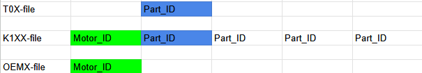

A part file holds one part ID per row. A component file holds the engine ID plus the IDs of all parts built into that engine. A vehicle file holds the engine ID again. The engine file is therefore the bridge between the two other levels.

This gives us the chain **part -> engine -> vehicle** and therefore the manufacturer, the production date and the defect status of every part together with the OEM it ended up at.

# 1. Importing the Data

We import the three data levels one after another. Each level is loaded into its own dataframes, which are then collected in a list together with a list of names, so that all following preparation steps can be applied to every file in the same way.

## 1.1 Part Files

The manual lookup suggested that only T01 to T05 contain parts from manufacturer 202. Before importing anything we confirm that with code, because the manual search cannot prove that no other file was missed.

Every part ID carries the manufacturer number as its second block, so a part from our company always contains the sequence `-202-`. We scan all 38 part files for that sequence and stop at the first hit per file.

```python
import glob

# All part files, the pattern ignores backups and stray files in the folder
part_file_pattern = "data/Einzelteil/Einzelteil_T[0-9][0-9].*"
files_with_202 = []

for file in sorted(glob.glob(part_file_pattern)):
    found = False

    # The files are up to 600 MB so we read them in chunks and stop at the first hit
    with open(file, "rb") as handle:
        while True:
            chunk = handle.read(8 * 1024 * 1024)
            if not chunk:
                break
            if b"-202-" in chunk:
                found = True
                break

    if found:
        files_with_202.append(file)

print(f"Part files searched: {len(glob.glob(part_file_pattern))}")
print(f"Files containing manufacturer 202: {len(files_with_202)}")
for file in files_with_202:
    print(f"  {file}")
```

```
Part files searched: 38
Files containing manufacturer 202: 5
  data/Einzelteil\Einzelteil_T01.txt
  data/Einzelteil\Einzelteil_T02.txt
  data/Einzelteil\Einzelteil_T03.txt
  data/Einzelteil\Einzelteil_T04.csv
  data/Einzelteil\Einzelteil_T05.csv
```

**Result:** the code confirms the manual lookup. Manufacturer 202 appears in exactly five of the 38 part files, T01 to T05. Those five are the ones we import.

The five files use different field and row separators and two different date formats, so a helper function does the import and returns every file with the same columns and data types.

```python
import io
import warnings
from pathlib import Path

import pandas as pd
import plotly.express as px
import plotly.io as pio

warnings.filterwarnings("ignore")

# Embed the charts so they show up in the HTML export
pio.renderers.default = "notebook"
```

```python
# Path filenames and separators of the five part files
DATA = Path("data/Einzelteil")

FILES = {
    "T01": ("Einzelteil_T01.txt", b" | | ", b" "),
    "T02": ("Einzelteil_T02.txt", b"  ", b"\t"),
    "T03": ("Einzelteil_T03.txt", b"|", b"\x0b"),
    "T04": ("Einzelteil_T04.csv", b";", b"\n"),
    "T05": ("Einzelteil_T05.csv", b",", b"\n"),
}


def load(key):
    """Import one part file and return it with standardized columns."""
    filename, field_sep, row_sep = FILES[key]

    # Replace the separators in memory so one parser fits all files
    raw = (DATA / filename).read_bytes().replace(field_sep, b"\x01").replace(row_sep, b"\n")

    # Read the cleaned bytes into a dataframe
    df = pd.read_csv(io.BytesIO(raw), sep="\x01", na_values=["NA"], dtype=str)

    # Some files spread one column over a .x block a .y block and a plain block
    # Every row fills exactly one of them so we merge them back into one column
    for col in set(c.removesuffix(".x").removesuffix(".y") for c in df.columns):

        # Check if the column exists in both .x and .y forms
        if col + ".x" in df.columns and col + ".y" in df.columns:
            merged = df[col + ".x"].combine_first(df[col + ".y"])
            if col in df.columns:
                merged = merged.combine_first(df[col])
            df[col] = merged

    # Standardize the ID column name
    df["Part_ID"] = df.get("ID_" + key, df.get("Part_ID"))

    # Some files store the production date as days since 01.01.1970
    if "Produktionsdatum" not in df.columns and "Produktionsdatum_Origin_01011970" in df.columns:
        df["Produktionsdatum"] = pd.to_datetime("1970-01-01") + pd.to_timedelta(
            df["Produktionsdatum_Origin_01011970"].astype(float), unit="D"
        )

    # Convert the columns to their proper data types
    df["Produktionsdatum"] = pd.to_datetime(df["Produktionsdatum"])
    df["Fehlerhaft_Datum"] = pd.to_datetime(df["Fehlerhaft_Datum"])
    df["Fehlerhaft_Fahrleistung"] = df["Fehlerhaft_Fahrleistung"].str.replace(",", ".", regex=False).astype(float)

    int_columns = ["Herstellernummer", "Werksnummer", "Fehlerhaft"]
    df[int_columns] = df[int_columns].astype("Int64")

    columns = [
        "Part_ID",
        "Herstellernummer",
        "Werksnummer",
        "Produktionsdatum",
        "Fehlerhaft",
        "Fehlerhaft_Datum",
        "Fehlerhaft_Fahrleistung",
    ]
    return df[columns].reset_index(drop=True)


part_names = ["T01", "T02", "T03", "T04", "T05"]
part_files = []

for name in part_names:
    part_files.append(load(name))
```

## 1.2 Component Files

The engine components are the link between the parts and the vehicles. We import the four K1 engine variants. Each file lists the part IDs that were built into one engine together with that engine ID.

```python
KOMPONENTE = "data/Komponente/Bestandteile_Komponente_"

komponente_k1be1 = pd.read_csv(KOMPONENTE + "K1BE1.csv", sep=";").drop(columns=["Unnamed: 0"])
komponente_k1di1 = pd.read_csv(KOMPONENTE + "K1DI1.csv", sep=";").drop(columns=["Unnamed: 0"])
komponente_k1be2 = pd.read_csv(KOMPONENTE + "K1BE2.csv", sep=";").drop(columns=["Unnamed: 0"])
komponente_k1di2 = pd.read_csv(KOMPONENTE + "K1DI2.csv", sep=";").drop(columns=["Unnamed: 0"])

component_names = ["K1BE1", "K1DI1", "K1BE2", "K1DI2"]
component_files = [komponente_k1be1, komponente_k1di1, komponente_k1be2, komponente_k1di2]
```

## 1.3 Vehicle Files

The vehicle files record which engine is installed in which car. We import both OEM1 and both OEM2 vehicle types, because OEM1 is required for the defect comparison and OEM2 is required to see the complete market when measuring engine penetration.

```python
FAHRZEUG = "data/Fahrzeug/Bestandteile_Fahrzeuge_"

oem11 = pd.read_csv(FAHRZEUG + "OEM1_Typ11.csv", sep=";").drop(columns=["Unnamed: 0"], errors="ignore")
oem12 = pd.read_csv(FAHRZEUG + "OEM1_Typ12.csv", sep=";").drop(columns=["Unnamed: 0"], errors="ignore")
oem21 = pd.read_csv(FAHRZEUG + "OEM2_Typ21.csv", sep=";").drop(columns=["Unnamed: 0"], errors="ignore")
oem22 = pd.read_csv(FAHRZEUG + "OEM2_Typ22.csv", sep=";").drop(columns=["Unnamed: 0"], errors="ignore")

vehicle_names = ["OEM1 Typ11", "OEM1 Typ12", "OEM2 Typ21", "OEM2 Typ22"]
vehicle_files = [oem11, oem12, oem21, oem22]
```

## 1.4 Overview of the Imported Data

We display the size and the first rows of every imported file to verify that the import worked and that the columns are the ones we expect.

```python
for i in range(len(part_files)):
    print(f"{part_names[i]} | Shape: {part_files[i].shape}")
    display(part_files[i].head(2))

for i in range(len(component_files)):
    print(f"{component_names[i]} | Shape: {component_files[i].shape}")
    display(component_files[i].head(2))

for i in range(len(vehicle_files)):
    print(f"{vehicle_names[i]} | Shape: {vehicle_files[i].shape}")
    display(vehicle_files[i].head(2))
```

```
T01 | Shape: (3204104, 7)
```

|  | Part_ID | Herstellernummer | Werksnummer | Produktionsdatum | Fehlerhaft | Fehlerhaft_Datum | Fehlerhaft_Fahrleistung |
| --- | --- | --- | --- | --- | --- | --- | --- |
| 0 | 1-201-2011-247 | 201 | 2011 | 2008-11-07 | 0 | NaT | 0.0 |
| 1 | 1-201-2011-429 | 201 | 2011 | 2008-11-07 | 0 | NaT | 0.0 |

```
T02 | Shape: (3204104, 7)
```

|  | Part_ID | Herstellernummer | Werksnummer | Produktionsdatum | Fehlerhaft | Fehlerhaft_Datum | Fehlerhaft_Fahrleistung |
| --- | --- | --- | --- | --- | --- | --- | --- |
| 0 | 2-201-2011-239 | 201 | 2011 | 2008-11-07 | 1 | 2010-04-09 | 38354.158904 |
| 1 | 2-201-2011-304 | 201 | 2011 | 2008-11-07 | 0 | NaT | 0.000000 |

```
T03 | Shape: (1192630, 7)
```

|  | Part_ID | Herstellernummer | Werksnummer | Produktionsdatum | Fehlerhaft | Fehlerhaft_Datum | Fehlerhaft_Fahrleistung |
| --- | --- | --- | --- | --- | --- | --- | --- |
| 0 | 3-202-2023-249 | 202 | 2023 | 2008-11-07 | 0 | NaT | 0.0 |
| 1 | 3-202-2022-8 | 202 | 2022 | 2008-11-07 | 0 | NaT | 0.0 |

```
T04 | Shape: (1192630, 7)
```

|  | Part_ID | Herstellernummer | Werksnummer | Produktionsdatum | Fehlerhaft | Fehlerhaft_Datum | Fehlerhaft_Fahrleistung |
| --- | --- | --- | --- | --- | --- | --- | --- |
| 0 | 4-204-2043-113 | 204 | 2043 | 2008-11-07 | 0 | NaT | 0.0 |
| 1 | 4-202-2023-18 | 202 | 2023 | 2008-11-07 | 0 | NaT | 0.0 |

```
T05 | Shape: (1192630, 7)
```

|  | Part_ID | Herstellernummer | Werksnummer | Produktionsdatum | Fehlerhaft | Fehlerhaft_Datum | Fehlerhaft_Fahrleistung |
| --- | --- | --- | --- | --- | --- | --- | --- |
| 0 | 5-201-2012-82 | 201 | 2012 | 2008-11-07 | 1 | 2010-07-10 | 43163.430137 |
| 1 | 5-201-2012-172 | 201 | 2012 | 2008-11-07 | 0 | NaT | 0.000000 |

```
K1BE1 | Shape: (1192630, 5)
```

|  | ID_T1 | ID_T2 | ID_T3 | ID_T4 | ID_K1BE1 |
| --- | --- | --- | --- | --- | --- |
| 0 | 1-201-2011-45 | 2-201-2011-161 | 3-202-2023-14 | 4-202-2023-20 | K1BE1-101-1011-1 |
| 1 | 1-201-2011-429 | 2-201-2011-239 | 3-202-2023-16 | 4-202-2023-51 | K1BE1-101-1011-2 |

```
K1DI1 | Shape: (1192630, 5)
```

|  | ID_T1 | ID_T2 | ID_T5 | ID_T6 | ID_K1DI1 |
| --- | --- | --- | --- | --- | --- |
| 0 | 1-204-2044-27 | 2-201-2011-144 | 5-202-2012-89 | 6-203-2032-5 | K1DI1-101-1041-1 |
| 1 | 1-202-2021-32 | 2-202-2022-577 | 5-202-2012-155 | 6-203-2032-79 | K1DI1-101-1041-2 |

```
K1BE2 | Shape: (409422, 5)
```

|  | ID_T1 | ID_T2 | ID_T7 | ID_T8 | ID_K1BE2 |
| --- | --- | --- | --- | --- | --- |
| 0 | 1-202-2021-339 | 2-202-2022-171 | 7-203-2031-9 | 8-204-2041-12 | K1BE2-101-1011-1 |
| 1 | 1-201-2011-57 | 2-201-2011-260 | 7-201-2012-30 | 8-204-2041-38 | K1BE2-101-1011-2 |

```
K1DI2 | Shape: (409422, 5)
```

|  | ID_T1 | ID_T2 | ID_T9 | ID_T10 | ID_K1DI2 |
| --- | --- | --- | --- | --- | --- |
| 0 | 1-204-2044-183 | 2-202-2022-551 | 9-204-2043-1 | 10-204-2042-3 | K1DI2-103-1031-1 |
| 1 | 1-201-2011-246 | 2-202-2022-738 | 9-204-2043-35 | 10-204-2042-41 | K1DI2-103-1031-2 |

```
OEM1 Typ11 | Shape: (1977164, 5)
```

|  | ID_Karosserie | ID_Schaltung | ID_Sitze | ID_Motor | ID_Fahrzeug |
| --- | --- | --- | --- | --- | --- |
| 0 | K4-112-1121-3 | K3SG1-105-1051-32 | K2LE1-109-1091-2 | K1BE1-101-1011-7 | 11-1-11-1 |
| 1 | K4-112-1121-4 | K3SG1-105-1051-141 | K2ST1-109-1092-5 | K1BE1-101-1011-12 | 11-1-11-2 |

```
OEM1 Typ12 | Shape: (408096, 5)
```

|  | ID_Karosserie | ID_Schaltung | ID_Sitze | ID_Motor | ID_Fahrzeug |
| --- | --- | --- | --- | --- | --- |
| 0 | K5-112-1122-1 | K3SG1-105-1051-4 | K2ST1-109-1092-1 | K1BE1-101-1011-90 | 12-1-12-1 |
| 1 | K5-112-1122-11 | K3AG1-105-1051-9 | K2ST1-109-1092-16 | K1BE1-101-1011-2 | 12-1-12-2 |

```
OEM2 Typ21 | Shape: (512354, 5)
```

|  | ID_Karosserie | ID_Schaltung | ID_Sitze | ID_Motor | ID_Fahrzeug |
| --- | --- | --- | --- | --- | --- |
| 0 | K6-113-1132-1 | K3AG2-108-1082-10 | K2ST2-109-1092-44 | K1BE2-101-1011-1 | 21-2-21-1 |
| 1 | K6-113-1132-2 | K3AG2-108-1082-6 | K2ST2-109-1092-42 | K1DI2-103-1031-1 | 21-2-21-2 |

```
OEM2 Typ22 | Shape: (306490, 6)
```

|  | X1 | ID_Karosserie | ID_Schaltung | ID_Sitze | ID_Motor | ID_Fahrzeug |
| --- | --- | --- | --- | --- | --- | --- |
| 0 | 1 | K7-114-1142-1 | K3AG2-108-1082-9 | K2ST2-109-1092-2 | K1DI2-103-1031-2 | 22-2-21-1 |
| 1 | 2 | K7-114-1142-2 | K3AG2-108-1082-11 | K2ST2-109-1092-59 | K1BE2-101-1011-2 | 22-2-21-2 |

# 2. Data Preparation

Before the three levels can be merged, every file is checked for quality problems, cleaned, validated and explored. We apply the same steps to all three levels.

## 2.1 Quality Check

For the part files we inspect the manufacturers, the production date range, the values of the defect flag, duplicates and missing values. The component and vehicle files consist only of ID columns, so there we check the columns, duplicates and missing values.

```python
for i in range(len(part_files)):
    part = part_files[i]
    print(f"========== {part_names[i]} ==========")
    print(f"Shape:                    {part.shape}")
    print(f"Manufacturers:            {sorted(part['Herstellernummer'].dropna().unique())}")
    print(f"Production dates:         {part['Produktionsdatum'].min()} to {part['Produktionsdatum'].max()}")
    print(f"Faulty values:            {sorted(part['Fehlerhaft'].dropna().unique())}")
    print(f"Duplicates:               {part.duplicated().sum()}")
    print(f"Missing values:           {part.isnull().sum().sum()}")
    print(f"Negative mileage:         {(part['Fehlerhaft_Fahrleistung'] < 0).sum()}")
    print(f"Defect before production: {(part['Fehlerhaft_Datum'] < part['Produktionsdatum']).sum()}")
    print(f"Faulty without a date:    {((part['Fehlerhaft'] == 1) & part['Fehlerhaft_Datum'].isna()).sum()}")
    print()

for i in range(len(component_files)):
    component = component_files[i]
    print(f"========== {component_names[i]} ==========")
    print(f"Shape:                    {component.shape}")
    print(f"Columns:                  {list(component.columns)}")
    print(f"Duplicates:               {component.duplicated().sum()}")
    print(f"Missing values:           {component.isnull().sum().sum()}")
    print()

for i in range(len(vehicle_files)):
    vehicle = vehicle_files[i]
    print(f"========== {vehicle_names[i]} ==========")
    print(f"Shape:                    {vehicle.shape}")
    print(f"Columns:                  {list(vehicle.columns)}")
    print(f"Duplicates:               {vehicle.duplicated().sum()}")
    print(f"Missing values:           {vehicle.isnull().sum().sum()}")
    print()
```

```
========== T01 ==========
Shape:                    (3204104, 7)
Manufacturers:            [np.int64(201), np.int64(202), np.int64(204)]
Production dates:         2008-11-07 00:00:00 to 2016-11-04 00:00:00
Faulty values:            [np.int64(0), np.int64(1)]
```

```
Duplicates:               0
Missing values:           2499776
Negative mileage:         0
Defect before production: 0
Faulty without a date:    0

========== T02 ==========
Shape:                    (3204104, 7)
Manufacturers:            [np.int64(201), np.int64(202)]
Production dates:         2008-11-07 00:00:00 to 2016-11-05 00:00:00
Faulty values:            [np.int64(0), np.int64(1)]
```

```
Duplicates:               0
Missing values:           2884102
Negative mileage:         0
Defect before production: 0
Faulty without a date:    0

========== T03 ==========
Shape:                    (1192630, 7)
Manufacturers:            [np.int64(201), np.int64(202)]
Production dates:         2008-11-07 00:00:00 to 2016-11-05 00:00:00
Faulty values:            [np.int64(0), np.int64(1)]
```

```
Duplicates:               0
Missing values:           1073525
Negative mileage:         0
Defect before production: 0
Faulty without a date:    0

========== T04 ==========
Shape:                    (1192630, 7)
Manufacturers:            [np.int64(202), np.int64(204)]
Production dates:         2008-11-07 00:00:00 to 2016-11-05 00:00:00
Faulty values:            [np.int64(0), np.int64(1)]
```

```
Duplicates:               0
Missing values:           1073015
Negative mileage:         1390
Defect before production: 0
Faulty without a date:    0

========== T05 ==========
Shape:                    (1192630, 7)
Manufacturers:            [np.int64(201), np.int64(202)]
Production dates:         2008-11-07 00:00:00 to 2016-10-31 00:00:00
Faulty values:            [np.int64(0), np.int64(1)]
```

```
Duplicates:               0
Missing values:           1073826
Negative mileage:         0
Defect before production: 0
Faulty without a date:    0

========== K1BE1 ==========
Shape:                    (1192630, 5)
Columns:                  ['ID_T1', 'ID_T2', 'ID_T3', 'ID_T4', 'ID_K1BE1']
```

```
Duplicates:               0
Missing values:           0

========== K1DI1 ==========
Shape:                    (1192630, 5)
Columns:                  ['ID_T1', 'ID_T2', 'ID_T5', 'ID_T6', 'ID_K1DI1']
```

```
Duplicates:               0
Missing values:           0

========== K1BE2 ==========
Shape:                    (409422, 5)
Columns:                  ['ID_T1', 'ID_T2', 'ID_T7', 'ID_T8', 'ID_K1BE2']
```

```
Duplicates:               0
Missing values:           0

========== K1DI2 ==========
Shape:                    (409422, 5)
Columns:                  ['ID_T1', 'ID_T2', 'ID_T9', 'ID_T10', 'ID_K1DI2']
```

```
Duplicates:               0
Missing values:           0

========== OEM1 Typ11 ==========
Shape:                    (1977164, 5)
Columns:                  ['ID_Karosserie', 'ID_Schaltung', 'ID_Sitze', 'ID_Motor', 'ID_Fahrzeug']
```

```
Duplicates:               0
Missing values:           0

========== OEM1 Typ12 ==========
Shape:                    (408096, 5)
Columns:                  ['ID_Karosserie', 'ID_Schaltung', 'ID_Sitze', 'ID_Motor', 'ID_Fahrzeug']
```

```
Duplicates:               0
Missing values:           0

========== OEM2 Typ21 ==========
Shape:                    (512354, 5)
Columns:                  ['ID_Karosserie', 'ID_Schaltung', 'ID_Sitze', 'ID_Motor', 'ID_Fahrzeug']
```

```
Duplicates:               0
Missing values:           0

========== OEM2 Typ22 ==========
Shape:                    (306490, 6)
Columns:                  ['X1', 'ID_Karosserie', 'ID_Schaltung', 'ID_Sitze', 'ID_Motor', 'ID_Fahrzeug']
Duplicates:               0
Missing values:           0
```

### Observations

**Part files**

**Component files**

- Every engine type is built from a different combination of part types:

| Engine | Part types | Rows |
| --- | --- | --- |
| K1BE1 | T1, T2, T3, T4 | 1,192,630 |
| K1DI1 | T1, T2, T5, T6 | 1,192,630 |
| K1BE2 | T1, T2, T7, T8 | 409,422 |
| K1DI2 | T1, T2, T9, T10 | 409,422 |

- Only T1 and T2 are installed in every engine, the rest is platform specific
- Manufacturer 202 produces T1 to T5. T6 to T10 come from competitors and are not part of the market share comparison, because that comparison is limited to the part types our company produces
- No duplicates and no missing values

**Vehicle files**

- OEM1 Typ11 holds 1,977,164 rows, OEM1 Typ12 holds 408,096, OEM2 Typ21 holds 512,354 and OEM2 Typ22 holds 306,490
- OEM2 Typ22 carries an additional column `X1`. It is a leftover row counter
- No duplicates and no missing values

## 2.2 Cleaning

The quality check found two problems:

1. **Implausible values:** 1,390 rows in T04 report a negative mileage at the moment of failure. A negative mileage cannot occur, and the true value cannot be reconstructed, so we set these entries to missing. The rows themselves stay, because their manufacturer, production date and defect flag are intact and needed for the analysis
2. **Extra column:** OEM2 Typ22 carries the leftover row counter `X1`

We still run the duplicate removal on all three levels so that the same rule is applied everywhere and the result is documented.

```python
# Set the implausible negative mileage values to missing
for i in range(len(part_files)):
    negative = part_files[i]["Fehlerhaft_Fahrleistung"] < 0
    part_files[i].loc[negative, "Fehlerhaft_Fahrleistung"] = float("nan")
    print(f"{part_names[i]}: {negative.sum()} negative mileage values set to missing")

# Remove the leftover row counter from OEM2 Typ22
vehicle_files[3] = vehicle_files[3].drop(columns=["X1"])

# Part files: remove duplicates and rows without a part ID
for i in range(len(part_files)):
    rows_before = len(part_files[i])
    part = part_files[i].drop_duplicates()
    part = part.dropna(subset=["Part_ID"])
    part_files[i] = part.reset_index(drop=True)
    print(f"{part_names[i]}: {rows_before} -> {len(part_files[i])} rows")

# Component files: remove duplicates
for i in range(len(component_files)):
    rows_before = len(component_files[i])
    component_files[i] = component_files[i].drop_duplicates().reset_index(drop=True)
    print(f"{component_names[i]}: {rows_before} -> {len(component_files[i])} rows")

# Vehicle files: remove duplicates
for i in range(len(vehicle_files)):
    rows_before = len(vehicle_files[i])
    vehicle_files[i] = vehicle_files[i].drop_duplicates().reset_index(drop=True)
    print(f"{vehicle_names[i]}: {rows_before} -> {len(vehicle_files[i])} rows")

# Point the individual variables at the cleaned dataframes
komponente_k1be1, komponente_k1di1, komponente_k1be2, komponente_k1di2 = component_files
oem11, oem12, oem21, oem22 = vehicle_files
```

```
T01: 0 negative mileage values set to missing
```

```
T02: 0 negative mileage values set to missing
T03: 0 negative mileage values set to missing
T04: 1390 negative mileage values set to missing
T05: 0 negative mileage values set to missing
```

```
T01: 3204104 -> 3204104 rows
```

```
T02: 3204104 -> 3204104 rows
```

```
T03: 1192630 -> 1192630 rows
```

```
T04: 1192630 -> 1192630 rows
```

```
T05: 1192630 -> 1192630 rows
```

```
K1BE1: 1192630 -> 1192630 rows
```

```
K1DI1: 1192630 -> 1192630 rows
```

```
K1BE2: 409422 -> 409422 rows
```

```
K1DI2: 409422 -> 409422 rows
```

```
OEM1 Typ11: 1977164 -> 1977164 rows
```

```
OEM1 Typ12: 408096 -> 408096 rows
```

```
OEM2 Typ21: 512354 -> 512354 rows
OEM2 Typ22: 306490 -> 306490 rows
```

### Cleaning Result

The 1,390 negative mileage values in T04 are now missing. No file lost a row, because every affected row still holds a valid manufacturer, production date and defect flag. The extra column was dropped from OEM2 Typ22, so all four vehicle files share the same five columns.

## 2.3 Validation

The IDs in this dataset are not plain keys, they encode information that can be checked against the other columns. That gives us a way to validate the data instead of trusting it.

- A part ID such as `1-201-2011-247` encodes the part type, the manufacturer number and the plant number. We compare all three against the corresponding columns and confirm that the production dates fall within a plausible range
- A component ID such as `K1BE1-101-1011-11` starts with the engine type. We confirm that every engine ID carries the prefix of its own file and that no engine is listed twice
- A vehicle references its engine through `ID_Motor`. We confirm that every vehicle refers to a K1 engine and that no vehicle ID appears twice

```python
# Part files: check the values encoded in the part ID
for i in range(len(part_files)):
    part = part_files[i]
    id_parts = part["Part_ID"].str.split("-", expand=True)

    wrong_type = (id_parts[0].astype(int) != int(part_names[i][1:])).sum()
    wrong_manufacturer = (id_parts[1].astype(int) != part["Herstellernummer"]).sum()
    wrong_plant = (id_parts[2].astype(int) != part["Werksnummer"]).sum()
    wrong_date = ((part["Produktionsdatum"] < "2008-01-01")
                  | (part["Produktionsdatum"] > "2017-01-01")).sum()

    print(f"========== {part_names[i]} ==========")
    print(f"Part type mismatches:    {wrong_type}")
    print(f"Manufacturer mismatches: {wrong_manufacturer}")
    print(f"Plant mismatches:        {wrong_plant}")
    print(f"Implausible dates:       {wrong_date}")
    print()

# Component files: check the engine ID prefix and uniqueness
for i in range(len(component_files)):
    component = component_files[i]
    engine_column = "ID_" + component_names[i]
    wrong_prefix = (~component[engine_column].str.startswith(component_names[i] + "-")).sum()

    print(f"========== {component_names[i]} ==========")
    print(f"Wrong engine ID prefix:  {wrong_prefix}")
    print(f"Repeated engine IDs:     {component[engine_column].duplicated().sum()}")
    print()

# Vehicle files: check the engine reference and uniqueness
for i in range(len(vehicle_files)):
    vehicle = vehicle_files[i]
    wrong_engine = (~vehicle["ID_Motor"].str.startswith("K1")).sum()

    print(f"========== {vehicle_names[i]} ==========")
    print(f"Engines that are not K1: {wrong_engine}")
    print(f"Repeated vehicle IDs:    {vehicle['ID_Fahrzeug'].duplicated().sum()}")
    print()
```

```
========== T01 ==========
Part type mismatches:    0
Manufacturer mismatches: 0
Plant mismatches:        0
Implausible dates:       0
```

```
========== T02 ==========
Part type mismatches:    0
Manufacturer mismatches: 0
Plant mismatches:        0
Implausible dates:       0
```

```
========== T03 ==========
Part type mismatches:    0
Manufacturer mismatches: 0
Plant mismatches:        0
Implausible dates:       0
```

```
========== T04 ==========
Part type mismatches:    0
Manufacturer mismatches: 0
Plant mismatches:        0
Implausible dates:       0
```

```
========== T05 ==========
Part type mismatches:    0
Manufacturer mismatches: 0
Plant mismatches:        596315
Implausible dates:       0

========== K1BE1 ==========
Wrong engine ID prefix:  0
Repeated engine IDs:     0

========== K1DI1 ==========
Wrong engine ID prefix:  0
```

```
Repeated engine IDs:     0

========== K1BE2 ==========
Wrong engine ID prefix:  0
Repeated engine IDs:     0

========== K1DI2 ==========
Wrong engine ID prefix:  0
Repeated engine IDs:     0

========== OEM1 Typ11 ==========
Engines that are not K1: 0
```

```
Repeated vehicle IDs:    0

========== OEM1 Typ12 ==========
Engines that are not K1: 0
Repeated vehicle IDs:    0

========== OEM2 Typ21 ==========
Engines that are not K1: 0
Repeated vehicle IDs:    0

========== OEM2 Typ22 ==========
Engines that are not K1: 0
Repeated vehicle IDs:    0
```

### Investigating the Plant Number Mismatch

T05 reports a plant mismatch for exactly 596,315 rows, which is the number of parts from manufacturer 202 in that file. To find out which of the two values is wrong we compare the plant number encoded in the part ID against the `Werksnummer` column, and we list which plants each manufacturer actually operates across all part files.

```python
# Compare the plant number from the ID against the column
t05 = part_files[4]
id_plant = t05["Part_ID"].str.split("-", expand=True)[2].astype(int)
display(t05.assign(ID_Werk=id_plant).groupby(["Herstellernummer", "ID_Werk", "Werksnummer"]).size())

# List the plants each manufacturer operates
all_parts = pd.concat(part_files, ignore_index=True)
display(all_parts.groupby("Herstellernummer")["Werksnummer"].unique())
```

```
Herstellernummer  ID_Werk  Werksnummer
201               2012     2012           596315
202               2012     2023           596315
dtype: int64
```

```
Herstellernummer
201          [2011, 2012]
202    [2021, 2022, 2023]
204    [2044, 2043, 2042]
Name: Werksnummer, dtype: object
```

### Validation Result

**Part files.** All part IDs encode the correct part type and manufacturer number, and every production date falls within the plausible range.

One inconsistency was found in T05. All 596,315 parts from manufacturer 202 carry the plant number 2012 inside their part ID, while the `Werksnummer` column states 2023. The plant overview shows that 2012 belongs to manufacturer 201, while 202 operates the plants 2021, 2022 and 2023. The column is therefore correct and the plant number inside those part IDs does not follow the naming convention.

We document this instead of rewriting the IDs, because the part ID is the key that links the part files to the component files. The component file K1DI1 references exactly the same IDs, so both tables agree on the identifier and the merge is unaffected. Rewriting a key that is used consistently on both sides would create part IDs that do not exist in the source data without improving any result. The correct plant number remains available in the `Werksnummer` column, and none of the four questions uses it.

**Component and vehicle files.** Every engine ID carries the prefix of its own file, every vehicle refers to a K1 engine, and no engine or vehicle is listed twice.

## 2.4 Exploratory Data Analysis

The data is clean and validated, so we can now explore it. Four questions shape the expectations for the analysis: how large each manufacturer is, how the part types are split, which period the data covers, and how often parts are defective.

We tag every row with the file it came from and combine the five part files.

```python
# Tag every row with the file it came from
for i in range(len(part_files)):
    part_files[i]["Part_Type"] = part_names[i]

all_parts = pd.concat(part_files, ignore_index=True)
print(f"All part files combined: {all_parts.shape}")
display(all_parts.head(3))
display(all_parts.describe())
```

```
All part files combined: (9986098, 8)
```

|  | Part_ID | Herstellernummer | Werksnummer | Produktionsdatum | Fehlerhaft | Fehlerhaft_Datum | Fehlerhaft_Fahrleistung | Part_Type |
| --- | --- | --- | --- | --- | --- | --- | --- | --- |
| 0 | 1-201-2011-247 | 201 | 2011 | 2008-11-07 | 0 | NaT | 0.0 | T01 |
| 1 | 1-201-2011-429 | 201 | 2011 | 2008-11-07 | 0 | NaT | 0.0 | T01 |
| 2 | 1-201-2011-363 | 201 | 2011 | 2008-11-07 | 1 | 2009-09-30 | 12983.0 | T01 |

|  | Herstellernummer | Werksnummer | Produktionsdatum | Fehlerhaft | Fehlerhaft_Datum | Fehlerhaft_Fahrleistung |
| --- | --- | --- | --- | --- | --- | --- |
| count | 9986098.0 | 9986098.0 | 9986098 | 9986098.0 | 1381854 | 9.984708e+06 |
| mean | 201.999286 | 2022.016674 | 2012-11-03 09:01:54.831880 | 0.138378 | 2014-02-14 14:05:19.094781 | 3.761691e+03 |
| min | 201.0 | 2011.0 | 2008-11-07 00:00:00 | 0.0 | 2009-02-28 00:00:00 | 0.000000e+00 |
| 25% | 201.0 | 2012.0 | 2010-11-05 00:00:00 | 0.0 | 2012-02-17 00:00:00 | 0.000000e+00 |
| 50% | 202.0 | 2022.0 | 2012-11-03 00:00:00 | 0.0 | 2014-02-15 00:00:00 | 0.000000e+00 |
| 75% | 202.0 | 2023.0 | 2014-11-02 00:00:00 | 0.0 | 2016-02-13 00:00:00 | 0.000000e+00 |
| max | 204.0 | 2044.0 | 2016-11-05 00:00:00 | 1.0 | 2018-07-01 00:00:00 | 2.751890e+05 |
| std | 0.941989 | 10.101538 | NaN | 0.345296 | NaN | 1.067915e+04 |

### Manufacturer Distribution

```python
parts_per_manufacturer = all_parts.groupby("Herstellernummer").size().reset_index(name="count")
display(parts_per_manufacturer)

fig = px.bar(
    parts_per_manufacturer, x="Herstellernummer", y="count",
    title="Number of Parts per Manufacturer (T01 to T05)",
    labels={"Herstellernummer": "Manufacturer", "count": "Number of Parts"},
)
fig.show()
```

|  | Herstellernummer | count |
| --- | --- | --- |
| 0 | 201 | 2958451 |
| 1 | 202 | 5551986 |
| 2 | 204 | 1475661 |

[interactive chart not shown]

**Result:** 202 is the largest supplier with **5,551,986** parts, ahead of 201 with **2,958,451** and 204 with **1,475,661**.

The total is not yet the market share, because a manufacturer can be strong in one part type and absent in another.

### Split per Part Type

```python
parts_per_type = all_parts.groupby(["Part_Type", "Herstellernummer"]).size().reset_index(name="count")
display(parts_per_type)

fig = px.bar(
    parts_per_type, x="Part_Type", y="count", color="Herstellernummer", barmode="group",
    title="Parts per Type and Manufacturer",
    labels={"Part_Type": "Part Type", "count": "Number of Parts", "Herstellernummer": "Manufacturer"},
)
fig.show()
```

|  | Part_Type | Herstellernummer | count |
| --- | --- | --- | --- |
| 0 | T01 | 201 | 1281642 |
| 1 | T01 | 202 | 1281642 |
| 2 | T01 | 204 | 640820 |
| 3 | T02 | 201 | 961231 |
| 4 | T02 | 202 | 2242873 |
| 5 | T03 | 201 | 119263 |
| 6 | T03 | 202 | 1073367 |
| 7 | T04 | 202 | 357789 |
| 8 | T04 | 204 | 834841 |
| 9 | T05 | 201 | 596315 |
| 10 | T05 | 202 | 596315 |

[interactive chart not shown]

**Result:** the split differs strongly per part type.

- **T03**: 202 supplies almost everything
- **T02**: 202 clearly ahead of 201
- **T05**: even split between 202 and 201
- **T01**: three suppliers, 202 and 201 equal, 204 smaller
- **T04**: 204 produces more than twice as much as 202

T01 is the only part type with three suppliers. T04 is the only one where 202 trails, and also the only one without manufacturer 201. The exact shares follow in section 4.1.

### Period Covered

```python
all_parts["production_year"] = all_parts["Produktionsdatum"].dt.year
volume_per_year = all_parts.groupby(["production_year", "Herstellernummer"]).size().reset_index(name="count")

fig = px.line(
    volume_per_year, x="production_year", y="count", color="Herstellernummer", markers=True,
    title="Parts Produced per Year",
    labels={"production_year": "Year", "count": "Number of Parts", "Herstellernummer": "Manufacturer"},
)
fig.show()

all_parts = all_parts.drop(columns=["production_year"])
```

[interactive chart not shown]

**Result:** the data covers November 2008 to November 2016. Both edge years are incomplete, which explains the low values at the ends of the chart. From 2009 to 2015 the volumes are stable at roughly 371,000 parts for 201, 695,000 for 202 and 185,000 for 204.

The ratio between the manufacturers barely changes over the years. Market shares are therefore stable over time, and the date filter of the web application changes absolute numbers but not the overall picture.

### Defect Share per Part Type

```python
defects_per_type = all_parts.groupby("Part_Type")["Fehlerhaft"].agg(["count", "sum"]).reset_index()
defects_per_type["defect_rate"] = round(defects_per_type["sum"] / defects_per_type["count"] * 100, 2)
display(defects_per_type)

fig = px.bar(
    defects_per_type, x="Part_Type", y="defect_rate",
    title="Share of Defective Parts per Part Type",
    labels={"Part_Type": "Part Type", "defect_rate": "Defective Parts (%)"},
)
fig.show()
```

|  | Part_Type | count | sum | defect_rate |
| --- | --- | --- | --- | --- |
| 0 | T01 | 3204104 | 704328 | 21.98 |
| 1 | T02 | 3204104 | 320002 | 9.99 |
| 2 | T03 | 1192630 | 119105 | 9.99 |
| 3 | T04 | 1192630 | 119615 | 10.03 |
| 4 | T05 | 1192630 | 118804 | 9.96 |

[interactive chart not shown]

**Result:** T02 to T05 sit at almost exactly **10%** defective parts. T01 stands out with **21.98%**, more than twice as high.

T01 decides the overall quality picture. Whether that works for or against 202 depends on how the defects are split between the manufacturers, which is analysed in section 4.2.

## 2.5 Tidy Data

The component files are not tidy. One row describes one engine and holds several part IDs side by side in separate columns, so a single column does not contain a single variable. The merge needs the opposite shape: one row per installed part.

Melting also creates the first feature. The engine type is only visible in the file name and in the ID prefix, so we write it into its own column where it survives the merge.

At the same time we drop the columns for T06 to T10. Those part types come from other manufacturers, are not part of the comparison, and were never imported.

```python
# Keep only the part columns for T01 to T05
component_part_columns = {
    "K1BE1": ["ID_T1", "ID_T2", "ID_T3", "ID_T4"],
    "K1DI1": ["ID_T1", "ID_T2", "ID_T5"],
    "K1BE2": ["ID_T1", "ID_T2"],
    "K1DI2": ["ID_T1", "ID_T2"],
}

melted_components = []

for i in range(len(component_files)):
    name = component_names[i]
    engine_column = "ID_" + name

    # One row per installed part instead of one column per part type
    columns = component_part_columns[name] + [engine_column]
    melted = component_files[i][columns].melt(id_vars=engine_column, value_name="Part_ID")
    melted = melted.drop(columns=["variable"])
    melted = melted.rename(columns={engine_column: "Engine_ID"})
    melted["Engine_Type"] = name

    melted_components.append(melted)
    print(f"{name}: {component_files[i].shape} -> {melted.shape}")

engines_long = pd.concat(melted_components, ignore_index=True)
print(f"\nAll engines in long format: {engines_long.shape}")
display(engines_long.sort_values("Engine_ID").head(4))
```

```
K1BE1: (1192630, 5) -> (4770520, 3)
K1DI1: (1192630, 5) -> (3577890, 3)
K1BE2: (409422, 5) -> (818844, 3)
K1DI2: (409422, 5) -> (818844, 3)

All engines in long format: (9986098, 3)
```

|  | Engine_ID | Part_ID | Engine_Type |
| --- | --- | --- | --- |
| 0 | K1BE1-101-1011-1 | 1-201-2011-45 | K1BE1 |
| 1192630 | K1BE1-101-1011-1 | 2-201-2011-161 | K1BE1 |
| 2385260 | K1BE1-101-1011-1 | 3-202-2023-14 | K1BE1 |
| 3577890 | K1BE1-101-1011-1 | 4-202-2023-20 | K1BE1 |

### Tidy Result

The four component files became one table with 9,986,098 rows and three columns. Every row now says which part is installed in which engine and of which type that engine is. The row counts match the expectation: K1BE1 contributes four rows per engine, K1DI1 three, and the two smaller engines two each.

This table is the bridge between the part level and the vehicle level.

# 3. Creation of the Final Dataset

All three levels are now clean, validated and in the right shape. This section merges them into the single dataset that both the evaluation below and the web application work on.

### Chosen granularity

One row of the final dataset is **one part installed in one engine**. This is the finest level at which all four questions can still be answered:

- market share needs the manufacturer of every single part
- the defect comparison needs the defect flag of every single part
- engine penetration needs to know which parts sit in which engine
- the free time range needs the production date of every single part

Aggregating earlier would make at least one of those questions impossible.

```python
# Keep only the columns the final dataset needs
part_columns = ["Part_ID", "Part_Type", "Herstellernummer", "Produktionsdatum", "Fehlerhaft"]
parts_combined = all_parts[part_columns]

# Every part is installed in exactly one engine
final_df = parts_combined.merge(engines_long, how="inner", on="Part_ID")

print(f"Parts:                  {len(parts_combined)}")
print(f"Engine slots:           {len(engines_long)}")
print(f"Merged rows:            {len(final_df)}")
print(f"Unmatched parts:        {len(parts_combined) - len(final_df)}")
print(f"Unmatched engine slots: {len(engines_long) - len(final_df)}")
```

```
Parts:                  9986098
Engine slots:           9986098
Merged rows:            9986098
Unmatched parts:        0
Unmatched engine slots: 0
```

### Merge Result

Every part found its engine and every engine slot found its part. 9,986,098 rows on both sides and nothing unmatched, so the inner join loses nothing.

### Adding the OEM

The last feature marks which OEM an engine ended up at. We build the sets of engine IDs of both OEMs and mark every row accordingly: 1 for OEM1, 2 for OEM2, and 0 for an engine that was never installed.

```python
oem1_engines = set(oem11["ID_Motor"]) | set(oem12["ID_Motor"])
oem2_engines = set(oem21["ID_Motor"]) | set(oem22["ID_Motor"])

final_df["OEM_type"] = 0
final_df.loc[final_df["Engine_ID"].isin(oem1_engines), "OEM_type"] = 1
final_df.loc[final_df["Engine_ID"].isin(oem2_engines), "OEM_type"] = 2

display(final_df["OEM_type"].value_counts())
```

```
OEM_type
1    8348410
2    1637688
Name: count, dtype: int64
```

**Result:** no row carries the value 0, so every engine in the data was installed in a vehicle. 8,348,410 rows belong to OEM1 and 1,637,688 to OEM2.

### Renaming and validating

The columns still carry the German names of the raw files. We rename them to short English names so that the web application and the analysis read consistently, then validate the finished dataset.

```python
final_df = final_df.rename(columns={
    "Part_Type": "part_type",
    "Part_ID": "part_id",
    "Herstellernummer": "manufacturer",
    "Produktionsdatum": "production_date",
    "Fehlerhaft": "faulty",
    "Engine_ID": "engine_id",
    "Engine_Type": "engine_type",
})

final_df = final_df[["part_type", "part_id", "manufacturer", "production_date",
                     "faulty", "engine_id", "engine_type", "OEM_type"]]

display(final_df.head())

print(f"Shape:                 {final_df.shape}")
print(f"Missing values:        {final_df.isnull().sum().sum()}")
print(f"Duplicated rows:       {final_df.duplicated().sum()}")
print(f"Every part ID unique:  {final_df['part_id'].is_unique}")
print(f"Unique engines:        {final_df['engine_id'].nunique()}")
print(f"Engines without OEM:   {(final_df['OEM_type'] == 0).sum()}")
print()

display(final_df.groupby("part_type").size())
display(final_df.groupby("engine_type").size())
```

|  | part_type | part_id | manufacturer | production_date | faulty | engine_id | engine_type | OEM_type |
| --- | --- | --- | --- | --- | --- | --- | --- | --- |
| 0 | T01 | 1-201-2011-247 | 201 | 2008-11-07 | 0 | K1BE1-101-1011-90 | K1BE1 | 1 |
| 1 | T01 | 1-201-2011-429 | 201 | 2008-11-07 | 0 | K1BE1-101-1011-2 | K1BE1 | 1 |
| 2 | T01 | 1-201-2011-363 | 201 | 2008-11-07 | 1 | K1BE1-101-1011-11 | K1BE1 | 1 |
| 3 | T01 | 1-201-2011-30 | 201 | 2008-11-07 | 0 | K1BE1-101-1011-42 | K1BE1 | 1 |
| 4 | T01 | 1-201-2011-72 | 201 | 2008-11-07 | 1 | K1BE1-101-1011-55 | K1BE1 | 1 |

```
Shape:                 (9986098, 8)
Missing values:        0
```

```
Duplicated rows:       0
```

```
Every part ID unique:  True
```

```
Unique engines:        3204104
Engines without OEM:   0
```

```
part_type
T01    3204104
T02    3204104
T03    1192630
T04    1192630
T05    1192630
dtype: int64
```

```
engine_type
K1BE1    4770520
K1BE2     818844
K1DI1    3577890
K1DI2     818844
dtype: int64
```

### Validation Result

The final dataset holds 9,986,098 rows and 8 columns and passes every check:

- no missing values and no duplicated rows, so the merge left no unresolved keys
- every part ID appears exactly once, so no part was multiplied by the join
- 3,204,104 distinct engines, matching the number of engines in the component files
- no row without an OEM

The row counts per part type equal the file sizes, and the row counts per engine type follow the part combinations of each engine.

### Export

The dataset is written next to the notebook in two formats. The CSV is the format required by the submission checklist, and the Parquet file is what the web application loads by default because it is roughly ten times faster to read. The application falls back to the CSV when Parquet is unavailable.

```python
final_df.to_csv("SoSe26_Case_Study_finalData_Group_14.csv", index=False)
final_df.to_parquet("SoSe26_Case_Study_finalData_Group_14.parquet", index=False)
print("Final dataset exported.")
```

```
Final dataset exported.
```

# 4. Evaluation and Results

We now answer the four questions on the final dataset.

For all comparisons the manufacturers are split into two groups: our company 202 and everybody else as the competition.

```python
analysis_df = final_df.copy()
analysis_df["group"] = "Competition"
analysis_df.loc[analysis_df["manufacturer"] == 202, "group"] = "202"
```

## 4.1 Market Share

**Question: what is the market share of our parts compared to the competition?**

We count the parts per type and per group. The share is the number of our parts divided by all parts of that type. Since the comparison only makes sense for part types we actually produce, it covers T01 to T05.

```python
market = analysis_df.groupby(["part_type", "group"]).size().reset_index(name="count")

market_wide = market.pivot(index="part_type", columns="group", values="count")
market_wide["share_202"] = round(market_wide["202"] / market_wide.sum(axis=1) * 100, 2)
display(market_wide)

fig = px.bar(
    market, x="part_type", y="count", color="group", barmode="group",
    title="Parts Produced: 202 vs. Competition",
    labels={"part_type": "Part Type", "count": "Number of Parts", "group": "Manufacturer"},
)
fig.show()
```

| group part_type | 202 | Competition | share_202 |
| --- | --- | --- | --- |
| T01 | 1281642 | 1922462 | 40.0 |
| T02 | 2242873 | 961231 | 70.0 |
| T03 | 1073367 | 119263 | 90.0 |
| T04 | 357789 | 834841 | 30.0 |
| T05 | 596315 | 596315 | 50.0 |

[interactive chart not shown]

```python
by_manufacturer = final_df.groupby("manufacturer").size().reset_index(name="count")
by_manufacturer["share"] = round(by_manufacturer["count"] / by_manufacturer["count"].sum() * 100, 2)
display(by_manufacturer)

fig = px.pie(
    by_manufacturer, names="manufacturer", values="count",
    title="Market Share by Manufacturer",
)
fig.show()

parts_202 = len(final_df[final_df["manufacturer"] == 202])
share_202 = round(parts_202 / len(final_df) * 100, 2)
print(f"202 supplied {parts_202} of {len(final_df)} parts, a market share of {share_202}%.")
```

|  | manufacturer | count | share |
| --- | --- | --- | --- |
| 0 | 201 | 2958451 | 29.63 |
| 1 | 202 | 5551986 | 55.60 |
| 2 | 204 | 1475661 | 14.78 |

[interactive chart not shown]

```
202 supplied 5551986 of 9986098 parts, a market share of 55.6%.
```

### Interpretation

**Result:** 202 holds **55.60%** of the market, ahead of 201 with **29.63%** and 204 with **14.78%**.

**Per part type:**

| Part type | Share of 202 | Position |
| --- | --- | --- |
| T03 | **90.00%** | near monopoly |
| T02 | **70.00%** | strong lead |
| T05 | **50.00%** | even split |
| T01 | **40.00%** | behind the combined competition |
| T04 | **30.00%** | clearly behind |

**Interpretation:** the market leader claim holds overall and in T02, T03 and T05. It does not hold in T01 and T04. T04 is the weakest position at 30%.

The *Market share* tab of the application shows the same figures interactively, including a detail view per part type.

## 4.2 Defect Frequency

**Question: how does the defect frequency of our parts compare to the competition for OEM1 vehicles?**

The task restricts this comparison to engines that were installed in OEM1 vehicles, so we filter on `OEM_type == 1` first. The defect rate is the share of parts whose defect flag is set, calculated separately for each part type and group.

```python
oem1_df = analysis_df[analysis_df["OEM_type"] == 1]

defect_stats = oem1_df.groupby(["part_type", "group"]).agg(
    total=("faulty", "count"),
    faulty=("faulty", "sum"),
).reset_index()
defect_stats["defect_rate"] = round(defect_stats["faulty"] / defect_stats["total"] * 100, 2)
display(defect_stats)

fig = px.bar(
    defect_stats, x="part_type", y="defect_rate", color="group", barmode="group",
    title="Defect Rate: 202 vs. Competition (OEM1 vehicles only)",
    labels={"part_type": "Part Type", "defect_rate": "Defect Rate (%)", "group": "Manufacturer"},
)
fig.show()
```

|  | part_type | group | total | faulty | defect_rate |
| --- | --- | --- | --- | --- | --- |
| 0 | T01 | 202 | 954029 | 190610 | 19.98 |
| 1 | T01 | Competition | 1431231 | 333372 | 23.29 |
| 2 | T02 | 202 | 1669791 | 166642 | 9.98 |
| 3 | T02 | Competition | 715469 | 71451 | 9.99 |
| 4 | T03 | 202 | 1073367 | 107305 | 10.0 |
| 5 | T03 | Competition | 119263 | 11800 | 9.89 |
| 6 | T04 | 202 | 357789 | 35503 | 9.92 |
| 7 | T04 | Competition | 834841 | 84112 | 10.08 |
| 8 | T05 | 202 | 596315 | 59392 | 9.96 |
| 9 | T05 | Competition | 596315 | 59412 | 9.96 |

[interactive chart not shown]

```python
defect_overall = oem1_df.groupby("group").agg(
    total=("faulty", "count"),
    faulty=("faulty", "sum"),
).reset_index()
defect_overall["defect_rate"] = round(defect_overall["faulty"] / defect_overall["total"] * 100, 2)
display(defect_overall)

# Check the comparison without T01
without_t01 = oem1_df[oem1_df["part_type"] != "T01"].groupby("group").agg(
    total=("faulty", "count"),
    faulty=("faulty", "sum"),
).reset_index()
without_t01["defect_rate"] = round(without_t01["faulty"] / without_t01["total"] * 100, 2)
display(without_t01)
```

|  | group | total | faulty | defect_rate |
| --- | --- | --- | --- | --- |
| 0 | 202 | 4651291 | 559452 | 12.03 |
| 1 | Competition | 3697119 | 560147 | 15.15 |

|  | group | total | faulty | defect_rate |
| --- | --- | --- | --- | --- |
| 0 | 202 | 3697262 | 368842 | 9.98 |
| 1 | Competition | 2265888 | 226775 | 10.01 |

### Interpretation

**Result:** across all OEM1 parts our defect rate is **12.03%** against **15.15%** for the competition.

**Per part type:**

| Part type | 202 | Competition | Difference |
| --- | --- | --- | --- |
| T01 | **19.98%** | **23.29%** | +3.31 |
| T02 | 9.98% | 9.99% | equal |
| T03 | 10.00% | 9.89% | -0.11 |
| T04 | 9.92% | 10.08% | +0.16 |
| T05 | 9.96% | 9.96% | equal |

**Interpretation:** the advantage rests entirely on T01. Without T01 both groups sit at 9.98% and 10.01% and are indistinguishable. T01 is also the part type with the highest defect rate on both sides, so it is a weak spot of the product itself rather than a general strength of our production.

For the advertising this means the claim that our parts fail less often is correct and backed by the data, but it holds because we handle one difficult part type better, not because we are better everywhere. A promise of superior quality across the board would go beyond the data.

The *Quality analysis* tab of the application shows these rates for any selected period, plus the trend over time per part type.

## 4.3 Engine Penetration

**Question: in how many engines are parts from 202 installed?**

An engine counts as containing our parts as soon as at least one of its installed parts comes from manufacturer 202. We therefore count the distinct engines in total and the distinct engines that have at least one part from us.

```python
engines_total = final_df.groupby("engine_type")["engine_id"].nunique()
engines_202 = final_df[final_df["manufacturer"] == 202].groupby("engine_type")["engine_id"].nunique()

# Create a DataFrame to summarize the penetration of 202 parts in each engine type
penetration = pd.DataFrame({"total": engines_total, "with_202": engines_202})
penetration["share"] = round(penetration["with_202"] / penetration["total"] * 100, 2)
penetration["every_xth"] = round(penetration["total"] / penetration["with_202"], 2)
penetration = penetration.reset_index()
display(penetration)

fig = px.bar(
    penetration, x="share", y="engine_type", orientation="h",
    title="Share of Engines Containing 202 Parts",
    labels={"share": "Engines with 202 Parts (%)", "engine_type": "Engine Type"},
)
fig.show()
```

|  | engine_type | total | with_202 | share | every_xth |
| --- | --- | --- | --- | --- | --- |
| 0 | K1BE1 | 1192630 | 1177406 | 98.72 | 1.01 |
| 1 | K1BE2 | 409422 | 335695 | 81.99 | 1.22 |
| 2 | K1DI1 | 1192630 | 1085470 | 91.01 | 1.10 |
| 3 | K1DI2 | 409422 | 335729 | 82.00 | 1.22 |

[interactive chart not shown]

```python
all_engines = final_df["engine_id"].nunique()
engines_with_202 = final_df[final_df["manufacturer"] == 202]["engine_id"].nunique()

print(f"Engines in total:       {all_engines}")
print(f"Engines with 202 parts: {engines_with_202}")
print(f"Share:                  {round(engines_with_202 / all_engines * 100, 2)}%")
print(f"Slogan: In every {round(all_engines / engines_with_202, 2)}th engine there are parts from 202.")
```

```
Engines in total:       3204104
Engines with 202 parts: 2934300
Share:                  91.58%
Slogan: In every 1.09th engine there are parts from 202.
```

### Interpretation

**Result:** **91.58%** of all 3,204,104 engines contain at least one part from 202. In the requested wording this reads "In every 1.09th engine there are parts from 202".

**Per engine type:**

| Engine | Share with 202 parts |
| --- | --- |
| K1BE1 | **98.72%** |
| K1DI1 | **91.01%** |
| K1DI2 | **82.00%** |
| K1BE2 | **81.99%** |

**Interpretation:** the differences are structural rather than commercial. K1BE1 is built from four of our part types and K1DI1 from three, so the chance that at least one part comes from us is high. K1BE2 and K1DI2 only contain T1 and T2, which gives fewer opportunities. The 98.72% for K1BE1 is a consequence of that engine using more of the part types we supply.

The slogan is mathematically correct but unusable, because nobody counts in 1.09th engines. The same fact reads **"9 out of 10 engines contain parts from 202"**.

The *Engine penetration* tab of the application shows the share per engine type and a heat map of which part type appears in which engine.

## 4.4 Conclusion and Recommendations

### Answers to the four questions

| Question | Answer |
| --- | --- |
| Market share | **55.60%** of all parts in the types we produce. Market leader ahead of 201 with 29.63% and 204 with 14.78% |
| Defect frequency (OEM1) | **12.03%** for our parts against **15.15%** for the competition, an advantage of 3.12 points |
| Engine penetration | **91.58%** of all engines contain at least one part from us, which is 9 out of 10 |
| Dashboard | Implemented as a Streamlit application, described in section 5 |

### Recommendations for the marketing department

1. **Use the penetration figure as the headline.** "9 out of 10 engines contain parts from 202" is accurate. The literal slogan "in every 1.09th engine" should not be used.
2. **Keep the quality claim specific.** Our parts do fail less often, but the advantage comes almost entirely from T01. The defensible version is that in the most failure prone part type our defect rate is more than three points lower than the competition.
3. **Advertise T03 and T02, not T01 and T04.** With 90% and 70% these two carry the market leader message. In T01 we hold 40% and in T04 only 30%, so the same claim would be wrong there.
4. **State the reference period.** All numbers cover parts produced between November 2008 and November 2016. The ratios are stable across the years, so shorter periods give nearly the same shares, which the date filter of the dashboard makes verifiable.

### Limitations

- **The plant number in the T05 part IDs does not follow the naming convention** for the 596,315 parts from manufacturer 202. The part file and the component file use the same IDs, so the merge is unaffected, and the correct plant number is available in the `Werksnummer` column. None of the four questions uses it.
- **1,390 mileage readings in T04 were implausible** and are treated as missing. The column is not part of the final dataset, so no result depends on it.
- **Defects are counted at part level only.** The case study defines a vehicle as defective when a part, a component or the vehicle itself is marked defective. We answer the question that was asked, which is about the defect frequency of the parts, so component and vehicle level defects are outside this comparison.

# 5. Web Application

The results above are static. The marketing department needs to explore them, above all with the freely selectable production time range the task asks for. We therefore built an interactive dashboard on the final dataset.

### Starting the application

```
streamlit run SoSe26_Case_Study_App_Group_14.py
```

The application reads `SoSe26_Case_Study_finalData_Group_14.parquet` from the submission folder and falls back to the CSV of the same name if Parquet is not available. It needs no other file from the analysis, so the raw data folder can stay empty.

### Structure

The sidebar holds the logo and the date filter. That filter is the implementation of the freely selectable production time range: every number and every chart in the application recomputes on the selected range.

| Tab | Content |
| --- | --- |
| Overview | The key figures at a glance: market share, engine penetration, defect rate and the slogan, plus a written interpretation that adjusts to the selected period |
| Market share | Parts per type as 202 against the competition, the split by manufacturer, and a detail view per part type |
| Engine penetration | The slogan, the share per engine variant and a heat map showing which part type appears in which engine |
| Quality analysis | Defect rates for OEM1 vehicles per part type, plus the trend over time for a selectable part type |
| Data table | The final dataset with filters for part type, engine type and OEM, shown page by page because the browser cannot receive ten million rows at once |

### Design

The application uses light blue as the main colour, the Source Sans Pro font and our own logo from the `www` folder, as required by the task. The interpretations below the charts are generated from the filtered data rather than written as fixed text, so they stay correct for every selected period.

### Screenshots

**Overview**

[figure not shown]

The key figures at a glance. The sidebar holds the logo, the production date range and the group members.

**Market share**

[figure not shown]

Parts produced per type, 202 against the competition.

[figure not shown]

The split across all three manufacturers, followed by a dropdown to pick a single part type.

[figure not shown]

Detail view for the selected part type. Hovering a slice shows the exact number of parts.

**Engine penetration**

[figure not shown]

The slogan and the share of 202 parts across all engines.

[figure not shown]

Share of engines that contain at least one part from 202, per engine variant.

[figure not shown]

Which part type is installed in which engine, together with the underlying table.

**Quality analysis**

[figure not shown]

Defect rates for OEM1 vehicles, 202 against the competition, with a comment per part type.

[figure not shown]

Monthly trend for a selectable part type, here T01.

**Data table**

[figure not shown]

The final dataset with filters for part type, engine type and OEM. The table is paged because the browser cannot receive ten million rows at once.